```python
import numpy as np
import matplotlib.pyplot as plt
```

# 创建列

```python
a1 = np.array([4,6,8,2])
a2 = np.zeros(10)
a3 = np.ones(4)
a4 = np.random.random(10)
a5 = np.random.randn(10)
a6 = np.linspace(0, 10, 100)
a7 = np.arange(0, 10, 0.2)
```

```python
a6
```

```
array([ 0.        ,  0.1010101 ,  0.2020202 ,  0.3030303 ,  0.4040404 ,
        0.50505051,  0.60606061,  0.70707071,  0.80808081,  0.90909091,
        1.01010101,  1.11111111,  1.21212121,  1.31313131,  1.41414141,
        1.51515152,  1.61616162,  1.71717172,  1.81818182,  1.91919192,
        2.02020202,  2.12121212,  2.22222222,  2.32323232,  2.42424242,
        2.52525253,  2.62626263,  2.72727273,  2.82828283,  2.92929293,
        3.03030303,  3.13131313,  3.23232323,  3.33333333,  3.43434343,
        3.53535354,  3.63636364,  3.73737374,  3.83838384,  3.93939394,
        4.04040404,  4.14141414,  4.24242424,  4.34343434,  4.44444444,
        4.54545455,  4.64646465,  4.74747475,  4.84848485,  4.94949495,
        5.05050505,  5.15151515,  5.25252525,  5.35353535,  5.45454545,
        5.55555556,  5.65656566,  5.75757576,  5.85858586,  5.95959596,
        6.06060606,  6.16161616,  6.26262626,  6.36363636,  6.46464646,
        6.56565657,  6.66666667,  6.76767677,  6.86868687,  6.96969697,
        7.07070707,  7.17171717,  7.27272727,  7.37373737,  7.47474747,
        7.57575758,  7.67676768,  7.77777778,  7.87878788,  7.97979798,
        8.08080808,  8.18181818,  8.28282828,  8.38383838,  8.48484848,
        8.58585859,  8.68686869,  8.78787879,  8.88888889,  8.98989899,
        9.09090909,  9.19191919,  9.29292929,  9.39393939,  9.49494949,
        9.5959596 ,  9.6969697 ,  9.7979798 ,  9.8989899 , 10.        ])
```

# 列运算

```python
a1*2
```

```
array([ 8, 12, 16,  4])
```

```python
2*a1>10
```

[output not shown]

```python
1/a4 + a4
```

```
array([2.16776778e+00, 2.23667552e+00, 2.44569667e+00, 2.60592490e+00,
       2.42447558e+00, 2.00702610e+00, 3.29015634e+03, 2.00303543e+00,
       2.16323045e+00, 2.90590078e+00])
```

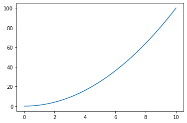

```python
plt.plot(a6, a6**2)
plt.show()
```

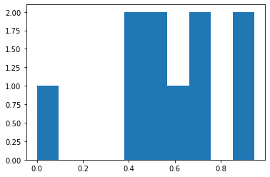

```python
plt.hist(a4)
plt.show()
```

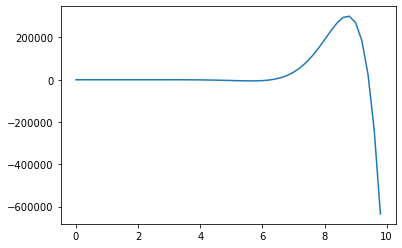

```python
def f(x):
    return x**2 * np.sin(x) / np.exp(-x)

plt.plot(a7, f(a7))
```

更多数学函数:

https://numpy.org/doc/stable/reference/routines.math.html

# 列的索引和切片

```python
a1 = np.array([2,4,6,8,10])
```

```python
a1[2]
```

```
6
```

```python
a1[2:]
```

```
array([ 6,  8, 10])
```

```python
a1[:-2]
```

```
array([2, 4, 6])
```

```python
a1[::2]
```

```
array([ 2,  6, 10])
```

```python
a1>3
```

```
array([False,  True,  True,  True,  True])
```

```python
#利用内部判断结果筛选
a1[a1>3]
```

```
array([ 4,  6,  8, 10])
```

```python
names = np.array(['Jim', 'Luke', 'Josh', 'Pete'])
#vectorize 相当于遍历列表
first_letter_j = np.vectorize(lambda s: s[0])(names)=='J'
names[first_letter_j]
```

```
array(['Jim', 'Josh'], dtype='<U4')
```

```python
a1%4
```

```
array([2, 0, 2, 0, 2], dtype=int32)
```

```python
a1%4==0
```

```
array([False,  True, False,  True, False])
```

```python
a1[a1%4==0]
```

```
array([4, 8])
```

# 微积分和统计函数

```python
#random.randn会产生标准差为1的随机数
a1 = 2*np.random.randn(10000) + 10
```

平均值、标准差、百分位

```python
np.mean(a1)
```

```
9.979134618033553
```

```python
np.std(a1)
```

```
1.9928989011691287
```

```python
#给出数据排列中大小在第百分之80的数字
np.percentile(a1, 80)
```

```
11.70188716158062
```

积分和微分

```python
x = np.linspace(1, 10, 100)
y = 1/x**2 * np.sin(x)
#求梯度
dydx = np.gradient(y,x)
#cumsum为累计和 积分就是一个个长方形面积累加
y_integral = np.cumsum(y) * (x[1]-x[0])
```

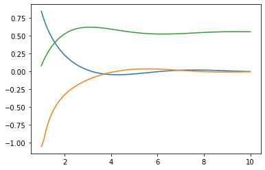

```python
plt.plot(x,y)
plt.plot(x,dydx)
plt.plot(x,y_integral)
```

# 例子

## 问题 1:

有函数 $y=e^{-x/10} \sin(x)$. 设置 10000 个 $x$ 的数列 ，范围是 $[0,10]$

1. 图表打印 $y$ 和 $x$ ，范围是 $[0, 10]$.
2. 计算$y$均值和方差 ，但条件是 $x$ 值在 $[4,7]$ 之间
3. 对于 $x$ 值在 $[4,7]$ 范围时, 找到一个值 $y_m$ 能够 让 80% $y$ 值小于 $y_m$
4. 图表打印 $dy/dx$ vs $x$
5. 找到 $dy/dx=0$ 时x的值

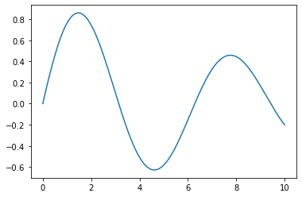

```python
#1
N = 10000
x = np.linspace(0, 10, N+1)
y = np.exp(-x/10) * np.sin(x)
plt.plot(x,y)
```

```python
#2
np.mean(y[(x>=4)*(x<=7)])
np.std(y[(x>=4)*(x<=7)])
```

```
0.31448753875085117
```

```python
#3
np.percentile(y[(x>=4)*(x<=7)], 80)
```

```
0.06145551274590662
```

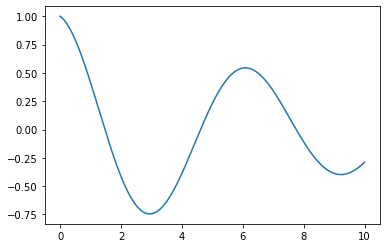

```python
#4
plt.plot(x, np.gradient(y,x))
```

```python
#5 求根 就是将相邻两个数相乘 直到某一对相乘出现负号 则两者异号 则判断为零点处
#dydx[1:] * dydx[:-1] 这个切片方式就是将数列移动一位，达到相邻数前后交叉
dydx = np.gradient(y,x)
x[1:][dydx[1:] * dydx[:-1] < 0]
```

[output not shown]

# 问题 2:

将 0 到 10000 之间的每个数字相加，但可以除以 4 或 7 的数字除外。在一行代码中执行此操作

```python
np.arange(0,10001,1)[(np.arange(0,10001,1)%4!=0)*(np.arange(0,10001,1)%7!=0)].sum()
```

```
32147142
```

## 问题 3:

考虑花瓣函数 $r(\theta) = 1+\frac{3}{4}\sin(3 \theta)$ ， $0 \leq \theta \leq 2 \pi$

1. 打出花瓣函数的样子 (找到X和Y的点)
2. 计算此面积积分 $A = \int_{0}^{2\pi} \frac{1}{2} r^2 d\theta$
3. 计算此曲线积分的长度 $L = \int_{0}^{2 \pi} \sqrt{r^2 + \left(\frac{dr}{d\theta}\right)^2} d\theta$

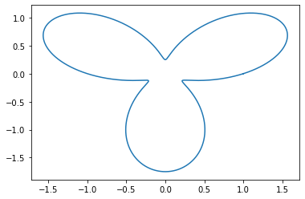

```python
# 1
theta = np.linspace(0, 2*np.pi, 10000)
r = 1 + 3/4 * np.sin(3*theta)
x = r*np.cos(theta)
y = r * np.sin(theta)
plt.plot(x,y)
```

```python
#2
A = 1/2 * sum(r**2) * (theta[1]-theta[0])
A
```

```
4.025479778096348
```

```python
L = sum(np.sqrt(r**2 + np.gradient(r, theta)**2)) * (theta[1]-theta[0])
L
```

```
11.626531213518831
```

## w问题 4:

一个黑体的发射功率为 $P = A \sigma \epsilon T^4$. 在测量了一颗恒星的温度后，你会发现 $T(t) = T_0 \frac{1}{1+e^{-kt}}$. 使用以下式子绘制恒星发出的总能量作为时间的函数 $E(t) = \int_{t'=0}^{t'=t} P(t') dt' $

该问题需要变化方程

$$P/(A \sigma \epsilon) = T^4 $$

$$P/(A \sigma \epsilon T_0^4) = ( \frac1{1+e^{-kt}} )^4 $$

此时可以将kt为自变量 而左侧则为 功率/功率 的无量纲数

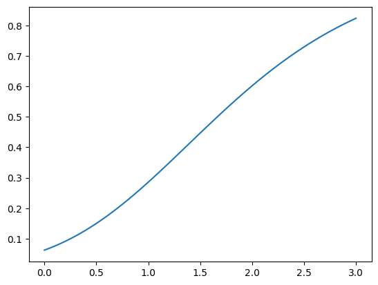

```python
kt = np.linspace(0, 3, 100)
P = (1/(1+np.exp(-kt)))**4
plt.plot(kt,P)
```

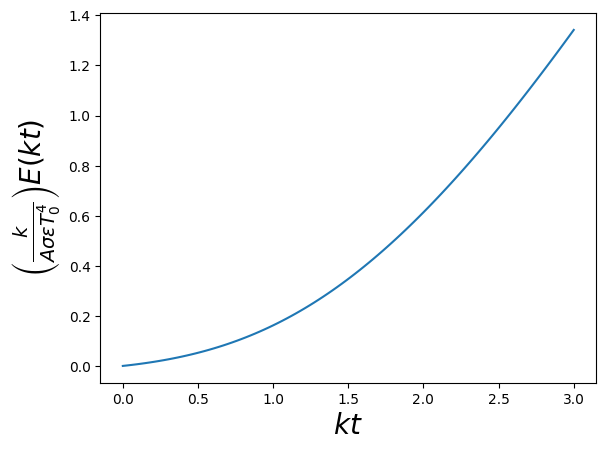

```python
E = np.cumsum(P) * (kt[1]-kt[0])
plt.plot(kt,E)
plt.xlabel('$kt$', fontsize=20)
plt.ylabel(r'$\left(\frac{k}{A \sigma \epsilon T_0^4}\right) E(kt)$', fontsize=20)
plt.show()
```

# 多维数列 矩阵

创建多维数列

```python
a1 = np.array([[4,6,4],[2,1,2],[5,6,7]])
```

```python
a1
```

```
array([[4, 6, 4],
       [2, 1, 2],
       [5, 6, 7]])
```

计算

```python
a1*2
```

```
array([[ 8, 12,  8],
       [ 4,  2,  4],
       [10, 12, 14]])
```

```python
2/a1
```

```
array([[0.5       , 0.33333333, 0.5       ],
       [1.        , 2.        , 1.        ],
       [0.4       , 0.33333333, 0.28571429]])
```

`ravel()` 可以将n维数列 扁平为1维数列

```python
a1.ravel()
```

```
array([4, 6, 4, 2, 1, 2, 5, 6, 7])
```

布尔计算

```python
a1>5
```

```
array([[False,  True, False],
       [False, False, False],
       [False,  True,  True]])
```

```python
a2 = np.random.randn(3,3)
a2
```

```
array([[-1.37124994,  0.07435976,  0.66096747],
       [ 0.30126566,  3.67107182,  0.46518364],
       [-0.94999396,  1.17356273,  0.84447869]])
```

```python
a2[a1>5]
```

```
array([0.07435976, 1.17356273, 0.84447869])
```

元素索引

```python
a1
```

```
array([[4, 6, 4],
       [2, 1, 2],
       [5, 6, 7]])
```

```python
a1[0]
```

```
array([4, 6, 4])
```

```python
a1[:,1]
```

```
array([6, 1, 6])
```

```python
a1[1:][:,1]
```

```
array([1, 6])
```

```python
a1
```

```
array([[4, 6, 4],
       [2, 1, 2],
       [5, 6, 7]])
```

```python
b1 = np.resize(a1, (6,6))
b1
```

```
array([[4, 6, 4, 2, 1, 2],
       [5, 6, 7, 4, 6, 4],
       [2, 1, 2, 5, 6, 7],
       [4, 6, 4, 2, 1, 2],
       [5, 6, 7, 4, 6, 4],
       [2, 1, 2, 5, 6, 7]])
```

```python
b1[0:5:2][:,3:]
```

```
array([[2, 1, 2],
       [5, 6, 7],
       [4, 6, 4]])
```

# 处理2维的方程和函数

二个维度，比如

```python
x = np.linspace(0, 10, 1000)
y = np.linspace(0, 5, 500)
```

```python
z = x**2 + y**2
```

```
---------------------------------------------------------------------------
ValueError                                Traceback (most recent call last)
Cell In[45], line 1
----> 1 z = x**2 + y**2

ValueError: operands could not be broadcast together with shapes (1000,) (500,)
```

需要使用 meshgrids 把x y的网格重叠起来

```python
xv, yv = np.meshgrid(x, y)
```

```python
zv = xv**2 + yv**2
```

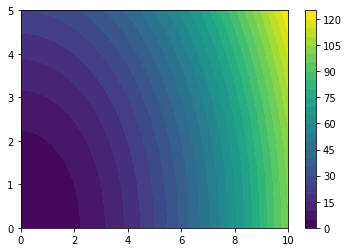

```python
plt.contourf(xv, yv, zv,levels=30)
plt.colorbar()
plt.show()
```

# 基础线性代数

## 矩阵操作

```python
A = np.array([[3, 2, 1],[5,-5,4],[6,0,1]])
b1 = np.array([1,2,3])
b2 = np.array([-1,2,-5])
```

```python
A
```

```
array([[ 3,  2,  1],
       [ 5, -5,  4],
       [ 6,  0,  1]])
```

```python
b1
```

```
array([1, 2, 3])
```

```python
A@b1
```

```
array([10,  7,  9])
```

```python
A.T
```

```
array([[ 3,  5,  6],
       [ 2, -5,  0],
       [ 1,  4,  1]])
```

```python
np.dot(b1, b2)
```

```
-12
```

```python
np.cross(b1, b2)
```

```
array([-16,   2,   4])
```

## 方程组

$ 3x + 2y + z = 4$

$ 5x -5y + 4z = 3$

$ 6x +z = 0$

```python
A = np.array([[3, 2, 1],[5,-5,4],[6,0,1]])
c = np.array([4,3,0])
```

```python
np.linalg.solve(A,c)
```

```
array([-0.49056604,  1.26415094,  2.94339623])
```

## 寻找本征值

```python
A = np.array([[4,2,2],[2,4,2],[2,2,4]])
A
```

```
array([[4, 2, 2],
       [2, 4, 2],
       [2, 2, 4]])
```

```python
np.linalg.eig(A)
```

```
(array([2., 8., 2.]),
 array([[-0.81649658,  0.57735027,  0.50669854],
        [ 0.40824829,  0.57735027, -0.80782419],
        [ 0.40824829,  0.57735027,  0.30112565]]))
```

```python
w, v = np.linalg.eig(A)
```

```python
A@v[:,1]
```

```
array([4.61880215, 4.61880215, 4.61880215])
```

```python
w[1]*v[:,1]
```

```
array([4.61880215, 4.61880215, 4.61880215])
```

# 例子

## 问题 1

有 $f(x,y) = e^{-(x^2+y^2)} \cdot \sin(x)$ ，范围 $-2 \leq x \leq 2$ 且 $-2 \leq y \leq 2$

1. 图表绘制 $f$ 填充等高线
2. 找出 $|f(x,y)|$ 值，对于指定$x$ 和 $y$ 的范围
3. 找出 $|f(x,y)|$ 值，范围是 $\sqrt{x^2+y^2}>0.5$

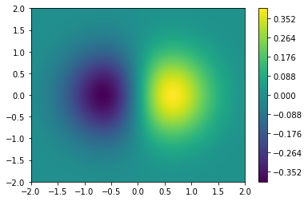

```python
#1
x = np.linspace(-2, 2, 1000)
y = np.linspace(-2, 2, 1000)
xv, yv = np.meshgrid(x, y)
f = np.exp(-xv**2-yv**2) * np.sin(xv)
plt.contourf(xv,yv,f, levels=100)
plt.colorbar()
```

```python
#2
sum(np.abs(f.ravel())) * np.diff(x)[0] * np.diff(y)[0]
```

```
1.4861858145125453
```

```python
# 3
sum(np.abs(f[xv**2+yv**2>0.25].ravel())) * np.diff(x)[0] * np.diff(y)[0]
```

```
1.344765293020408
```

## 问题 2

在检查一个充满电阻的电路后，您会发现 4 个指定点处的电压由下式给出

$ 3V_1 + 2V_2 + 3V_3 + 10V_4 = 4$

$ 2V_1 - 2V_2 + 5V_3 + 8V_4 = 1$

$ 3V_1 + 3V_2 + 4V_3 + 9V_4 = 3$

$ 3V_1 + 4V_2 - 3V_3 - 7V_4 = 2$

找出所有的电压值

```python
A = np.array([[3,2,3,10],[2,-2,5,8],[3,3,4,9],[3,4,-3,-7]])
v = np.array([4,1,3,2])
A
```

```
array([[ 3,  2,  3, 10],
       [ 2, -2,  5,  8],
       [ 3,  3,  4,  9],
       [ 3,  4, -3, -7]])
```

```python
np.linalg.solve(A,v)
```

```
array([ 0.78378378,  0.03603604, -0.67567568,  0.36036036])
```

## 问题 3 (较难)

电场由下式给出 $\vec{E}(z,t) = E_0 \cos (z-t) \hat{x} + 2E_0 \cos(z-t+\pi/2) \hat{y}$.

1. 求出磁场于范围 $z \in [0,4\pi]$ 和 $t \in [0,10]$ 中，主要使用公式 $\vec{B}(z,t) = \hat{z} \times \vec{E}(z,t)$
2. 计算 Poynting 向量 $\vec{S} = \vec{E} \times \vec{B}$ ，对于所有的 $z$ 和 $t$

```python
z = np.linspace(0, 4*np.pi, 100)
t = np.linspace(0, 10, 100)

tv, zv = np.meshgrid(t, z)

Ex = np.cos(zv-tv)
Ey = 2*np.cos(zv-tv+np.pi/2)
Ez = 0*tv
```

$E_x$ 图像如下 $t$ 当 $z=0$ 时

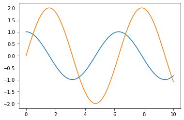

```python
plt.plot(t, Ex[0])
plt.plot(t, Ey[0])
```

$E_x$ 图像如下 $z$ 当 $t=0$ 时

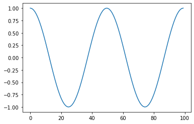

```python
plt.plot(Ex[:,0])
```

```python
E = np.array([Ex, Ey, Ez])
E = np.swapaxes(E, 0, -1)
```

```python
B = np.cross(np.array([0,0,1]), E)
E = np.swapaxes(E, 0, -1)
B = np.swapaxes(B, 0, -1)
```

```python
Bx, By, Bz = B
```

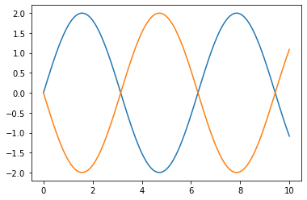

```python
plt.plot(t,Ey[0])
plt.plot(t,Bx[0])
```

```python
S = np.cross(np.swapaxes(E, 0, -1), np.swapaxes(B, 0, -1))
S = np.swapaxes(S, 0, -1)
Sx, Sy, Sz = S
```

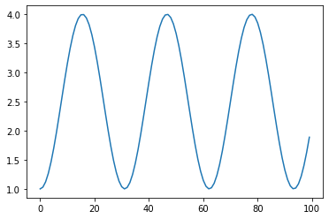

```python
plt.plot(Sz[0])
```

## 问题 4 (更难了)

- 使用本征值方法以及这个方法 $\frac{d^2 f}{dx^2} \approx \frac{f_{i+1} + f_{i-1} - 2f_i}{\Delta x^2}$ 来处理，其中条件为 $f_i = f(i \Delta x)$ 且 $i$ 是整数.
- 将其离散处理

```python
N = 1000
x = np.linspace(0,1,N+1)
dx = x[1]-x[0]

main_diag = -2*np.ones(N-1)
off_diag = np.ones(N-2)
derivative_matrix = (np.diag(main_diag) + np.diag(off_diag, k=1)+ np.diag(off_diag, k=-1))/dx**2
x2_matrix = np.diag((10*x[1:-1])**2)
LHS_matrix = derivative_matrix #+ x2_matrix
```

```python
w, v = np.linalg.eigh(LHS_matrix)
```

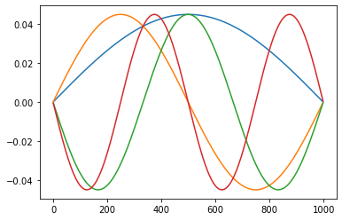

```python
plt.plot(-1*v[:,-1])
plt.plot(-1*v[:,-2])
plt.plot(-1*v[:,-3])
plt.plot(-1*v[:,-4])
```

```python
w[-1]
```

```
-9.869596283366647
```

```python
np.pi**2
```

```
9.869604401089358
```

```python
w[-2]
```

```
-39.4782877254107
```

```python
(2*np.pi)**2
```

```
39.47841760435743
```

```python
w[-3]
```

[output not shown]

```python
(3*np.pi)**2
```

```
88.82643960980423
```

```python
w[-4]
```

[output not shown]

```python
(4*np.pi)**2
```

```
157.91367041742973
```

# 基本数据集

```python
filepath='./data_sample.csv'
```

```python
data = np.loadtxt(filepath)
```

[output not shown]

```python
data = np.loadtxt(filepath, dtype='object')
data
```

```
array([',Person,Height', '1,Jim,172', '2,Mike,168', '3,Bob,182',
       '4,Susy,156', '5,Tim,170', '6,Frank,190'], dtype=object)
```

```python
data = np.loadtxt(filepath, dtype='object', delimiter=',')
data
```

```
array([['', 'Person', 'Height'],
       ['1', 'Jim', '172'],
       ['2', 'Mike', '168'],
       ['3', 'Bob', '182'],
       ['4', 'Susy', '156'],
       ['5', 'Tim', '170'],
       ['6', 'Frank', '190']], dtype=object)
```

```python
people, heights = np.loadtxt(filepath, dtype='object', delimiter=',', unpack=True)
```

```python
people
```

[output not shown]

```python
heights
```

```
array(['Height', '172', '168', '182', '156', '170', '190'], dtype=object)
```

```python
people, heights = np.loadtxt(filepath, dtype='object', delimiter=',', unpack=True, skiprows=1)
```

```python
people
```

```
array(['Jim', 'Mike', 'Bob', 'Susy', 'Tim', 'Frank'], dtype=object)
```

```python
heights
```

```
array(['172', '168', '182', '156', '170', '190'], dtype=object)
```

```python
people = people.astype(str)
heights = heights.astype(float)
```

```python
people
```

```
array(['Jim', 'Mike', 'Bob', 'Susy', 'Tim', 'Frank'], dtype='<U5')
```

```python
heights
```

```
array([172., 168., 182., 156., 170., 190.])
```